# Chiebuka_Onwuka_Project2_Part2

Project Title: Income Prediction and Demographic Patterns in the Adult Income Dataset

Topic / Question: Which factors are the strongest predictors of whether an individual

earns more than $50,000 per year?

Link to Data: [https://www.kaggle.com/datasets/anaghakp/adult\-income\-census](https://www.kaggle.com/datasets/anaghakp/adult%5C-income%5C-census)

We chose this dataset because it asks a straightforward but important question: what factors are linked to higher income. It also has both categorical and numerical variables, so it gives us a good chance to practice cleaning data, making visualizations, and doing analysis.

```python
#importing libraries
import numpy as np
import pandas as pd
import matplotlib.pyplot as plt
import seaborn as sns
```

```python
#Load the dataset
df = pd.read_csv('adult_income.csv')
```

```python
#first few rows
df.head()
```

|  | age | workclass | fnlwgt | education | education.num | marital.status | occupation | relationship | race | sex | native.country | income |
| --- | --- | --- | --- | --- | --- | --- | --- | --- | --- | --- | --- | --- |
| 0 | 17 | Private | 148522 | 11th | 7 | Never-married | occupation | Own-child | White | Male | United-States | <=50K |
| 1 | 17 | Private | 93235 | 12th | 8 | Never-married | occupation | Own-child | White | Female | United-States | <=50K |
| 2 | 17 | Private | 184924 | 9th | 5 | Never-married | occupation | Own-child | White | Male | United-States | <=50K |
| 3 | 17 | Private | 116626 | 11th | 7 | Never-married | occupation | Own-child | White | Male | United-States | <=50K |
| 4 | 17 | Private | 209949 | 11th | 7 | Never-married | occupation | Own-child | White | Female | United-States | <=50K |

```python
#last few rows
df.tail()
```

|  | age | workclass | fnlwgt | education | education.num | marital.status | occupation | relationship | race | sex | native.country | income |
| --- | --- | --- | --- | --- | --- | --- | --- | --- | --- | --- | --- | --- |
| 31942 | 90 | ? | 175444 | 7th-8th | 4 | Separated | ? | Not-in-family | White | Female | United-States | <=50K |
| 31943 | 90 | Federal-gov | 195433 | HS-grad | 9 | Married-civ-spouse | Craft-repair | Husband | White | Male | United-States | <=50K |
| 31944 | 90 | Private | 47929 | HS-grad | 9 | Married-civ-spouse | Machine-op-inspct | Husband | White | Male | United-States | <=50K |
| 31945 | 90 | ? | 313986 | HS-grad | 9 | Married-civ-spouse | ? | Husband | White | Male | United-States | >50K |
| 31946 | 90 | Private | 313749 | HS-grad | 9 | Widowed | Adm-clerical | Unmarried | White | Female | United-States | <=50K |

```python
#checks number of rows and columns
df.shape
```

```
(31947, 12)
```

```python
#prints column names
print(df.columns)
```

```
Index(['age', 'workclass', 'fnlwgt', 'education', 'education.num',
       'marital.status', 'occupation', 'relationship', 'race', 'sex',
       'native.country', 'income'],
      dtype='object')
```

```python
df.info()
```

```
<class 'pandas.core.frame.DataFrame'>
RangeIndex: 31947 entries, 0 to 31946
Data columns (total 12 columns):
 #   Column          Non-Null Count  Dtype
---  ------          --------------  -----
 0   age             31947 non-null  int64
 1   workclass       31947 non-null  object
 2   fnlwgt          31947 non-null  int64
 3   education       31947 non-null  object
 4   education.num   31947 non-null  int64
 5   marital.status  31947 non-null  object
 6   occupation      31947 non-null  object
 7   relationship    31947 non-null  object
 8   race            31947 non-null  object
 9   sex             31947 non-null  object
 10  native.country  31947 non-null  object
 11  income          31947 non-null  object
dtypes: int64(3), object(9)
memory usage: 2.9+ MB
```

```python
df.dtypes
```

```
age                int64
workclass         object
fnlwgt             int64
education         object
education.num      int64
marital.status    object
occupation        object
relationship      object
race              object
sex               object
native.country    object
income            object
dtype: object
```

```python
df.describe(include=[np.number])
```

|  | age | fnlwgt | education.num |
| --- | --- | --- | --- |
| count | 31947.000000 | 3.194700e+04 | 31947.000000 |
| mean | 38.570695 | 1.897319e+05 | 10.071149 |
| std | 13.646280 | 1.057567e+05 | 2.561430 |
| min | 17.000000 | 1.228500e+04 | 1.000000 |
| 25% | 28.000000 | 1.176275e+05 | 9.000000 |
| 50% | 37.000000 | 1.783120e+05 | 10.000000 |
| 75% | 48.000000 | 2.374535e+05 | 12.000000 |
| max | 90.000000 | 1.484705e+06 | 16.000000 |

```python
#null values
df.isnull().sum()
```

```
age               0
workclass         0
fnlwgt            0
education         0
education.num     0
marital.status    0
occupation        0
relationship      0
race              0
sex               0
native.country    0
income            0
dtype: int64
```

```python
#checks duplicates
df.duplicated().sum()
```

```
np.int64(65)
```

```python
df_duplicated = df[df.duplicated()]
df_duplicated
```

|  | age | workclass | fnlwgt | education | education.num | marital.status | occupation | relationship | race | sex | native.country | income |
| --- | --- | --- | --- | --- | --- | --- | --- | --- | --- | --- | --- | --- |
| 226 | 17 | Private | 183066 | 10th | 6 | Never-married | Other-service | Own-child | White | Female | United-States | <=50K |
| 268 | 17 | Private | 198146 | 11th | 7 | Never-married | Sales | Own-child | White | Female | United-States | <=50K |
| 603 | 18 | ? | 137363 | Some-college | 10 | Never-married | ? | Own-child | White | Female | United-States | <=50K |
| 899 | 18 | Private | 194561 | Some-college | 10 | Never-married | Other-service | Own-child | White | Male | United-States | <=50K |
| 1215 | 19 | ? | 220517 | Some-college | 10 | Never-married | ? | Own-child | White | Female | United-States | <=50K |
| ... | ... | ... | ... | ... | ... | ... | ... | ... | ... | ... | ... | ... |
| 23180 | 46 | Private | 133616 | Some-college | 10 | Divorced | Adm-clerical | Unmarried | White | Female | United-States | <=50K |
| 24862 | 49 | Private | 31267 | 7th-8th | 4 | Married-civ-spouse | Craft-repair | Husband | White | Male | United-States | <=50K |
| 24869 | 49 | Self-emp-not-inc | 43479 | Some-college | 10 | Married-civ-spouse | Craft-repair | Husband | White | Male | United-States | <=50K |
| 30947 | 66 | Private | 234743 | Some-college | 10 | Married-civ-spouse | Exec-managerial | Husband | White | Male | United-States | <=50K |
| 31922 | 90 | Private | 52386 | Some-college | 10 | Never-married | Other-service | Not-in-family | Asian-Pac-Islander | Male | United-States | <=50K |

65 rows × 12 columns

```python
#new age group column
df["age_group"] = pd.cut(df["age"],bins=[0,24,44,64,100],labels=["18-24", "25-44", "45-64", "65+"])
df[["age","age_group"]]
```

|  | age | age_group |
| --- | --- | --- |
| 0 | 17 | 18-24 |
| 1 | 17 | 18-24 |
| 2 | 17 | 18-24 |
| 3 | 17 | 18-24 |
| 4 | 17 | 18-24 |
| ... | ... | ... |
| 31942 | 90 | 65+ |
| 31943 | 90 | 65+ |
| 31944 | 90 | 65+ |
| 31945 | 90 | 65+ |
| 31946 | 90 | 65+ |

31947 rows × 2 columns

```python
#filter for people earning $50k+
high_income = df[df["income"] == ">50K"]
high_income
```

|  | age | workclass | fnlwgt | education | education.num | marital.status | occupation | relationship | race | sex | native.country | income | age_group |
| --- | --- | --- | --- | --- | --- | --- | --- | --- | --- | --- | --- | --- | --- |
| 944 | 19 | ? | 200790 | 12th | 8 | Married-civ-spouse | ? | Other-relative | White | Female | United-States | >50K | 18-24 |
| 1124 | 19 | Private | 323605 | 7th-8th | 4 | Never-married | Other-service | Not-in-family | White | Male | United-States | >50K | 18-24 |
| 2393 | 21 | Private | 334618 | Some-college | 10 | Never-married | Protective-serv | Not-in-family | Black | Female | United-States | >50K | 18-24 |
| 2520 | 21 | Private | 216070 | Assoc-acdm | 12 | Married-civ-spouse | Adm-clerical | Wife | Amer-Indian-Eskimo | Female | United-States | >50K | 18-24 |
| 2663 | 21 | Private | 548303 | HS-grad | 9 | Married-civ-spouse | Prof-specialty | Own-child | White | Male | Mexico | >50K | 18-24 |
| ... | ... | ... | ... | ... | ... | ... | ... | ... | ... | ... | ... | ... | ... |
| 31911 | 90 | Private | 175491 | HS-grad | 9 | Married-civ-spouse | Craft-repair | Husband | White | Male | Ecuador | >50K | 65+ |
| 31924 | 90 | Private | 51744 | Masters | 14 | Never-married | Exec-managerial | Not-in-family | Black | Male | United-States | >50K | 65+ |
| 31933 | 90 | Private | 88991 | Bachelors | 13 | Married-civ-spouse | Exec-managerial | Wife | White | Female | England | >50K | 65+ |
| 31939 | 90 | Private | 206667 | Masters | 14 | Married-civ-spouse | Prof-specialty | Wife | White | Female | United-States | >50K | 65+ |
| 31945 | 90 | ? | 313986 | HS-grad | 9 | Married-civ-spouse | ? | Husband | White | Male | United-States | >50K | 65+ |

7683 rows × 13 columns

```python
#filter for people with a bachelor's degree
bachelors = df[df["education"] == "Bachelors"]
bachelors
```

|  | age | workclass | fnlwgt | education | education.num | marital.status | occupation | relationship | race | sex | native.country | income | age_group |
| --- | --- | --- | --- | --- | --- | --- | --- | --- | --- | --- | --- | --- | --- |
| 989 | 19 | ? | 62534 | Bachelors | 13 | Never-married | ? | Own-child | Black | Female | Jamaica | <=50K | 18-24 |
| 1028 | 19 | Private | 100999 | Bachelors | 13 | Never-married | Prof-specialty | Own-child | White | Female | United-States | <=50K | 18-24 |
| 1863 | 20 | Private | 216436 | Bachelors | 13 | Never-married | Sales | Other-relative | Black | Female | United-States | <=50K | 18-24 |
| 2423 | 21 | Private | 226181 | Bachelors | 13 | Never-married | Handlers-cleaners | Not-in-family | White | Male | United-States | <=50K | 18-24 |
| 2473 | 21 | ? | 180303 | Bachelors | 13 | Never-married | ? | Not-in-family | Asian-Pac-Islander | Male | ? | <=50K | 18-24 |
| ... | ... | ... | ... | ... | ... | ... | ... | ... | ... | ... | ... | ... | ... |
| 31918 | 90 | Private | 221832 | Bachelors | 13 | Married-civ-spouse | Exec-managerial | Husband | White | Male | United-States | <=50K | 65+ |
| 31928 | 90 | Private | 40388 | Bachelors | 13 | Never-married | Exec-managerial | Not-in-family | White | Male | United-States | <=50K | 65+ |
| 31933 | 90 | Private | 88991 | Bachelors | 13 | Married-civ-spouse | Exec-managerial | Wife | White | Female | England | >50K | 65+ |
| 31934 | 90 | Private | 313749 | Bachelors | 13 | Never-married | Prof-specialty | Own-child | White | Female | United-States | <=50K | 65+ |
| 31940 | 90 | Private | 52386 | Bachelors | 13 | Never-married | Prof-specialty | Not-in-family | Asian-Pac-Islander | Male | United-States | <=50K | 65+ |

5208 rows × 13 columns

```python
#filter for people with a bachelor's and make more than $50k
bachelors_high_income = df[(df["education"] == "Bachelors") & (df["income"] == ">50K")]
bachelors_high_income
```

|  | age | workclass | fnlwgt | education | education.num | marital.status | occupation | relationship | race | sex | native.country | income | age_group |
| --- | --- | --- | --- | --- | --- | --- | --- | --- | --- | --- | --- | --- | --- |
| 3089 | 22 | Private | 233955 | Bachelors | 13 | Never-married | Prof-specialty | Not-in-family | Amer-Indian-Eskimo | Female | United-States | >50K | 18-24 |
| 3090 | 22 | Private | 100345 | Bachelors | 13 | Never-married | Craft-repair | Not-in-family | White | Male | United-States | >50K | 18-24 |
| 3091 | 22 | Private | 195532 | Bachelors | 13 | Never-married | Prof-specialty | Not-in-family | White | Female | United-States | >50K | 18-24 |
| 3835 | 23 | Private | 102942 | Bachelors | 13 | Never-married | occupation | Own-child | White | Female | United-States | >50K | 18-24 |
| 3836 | 23 | Self-emp-not-inc | 258298 | Bachelors | 13 | Never-married | occupation | Own-child | White | Male | United-States | >50K | 18-24 |
| ... | ... | ... | ... | ... | ... | ... | ... | ... | ... | ... | ... | ... | ... |
| 31827 | 79 | Self-emp-inc | 183686 | Bachelors | 13 | Married-civ-spouse | Sales | Husband | White | Male | United-States | >50K | 65+ |
| 31864 | 81 | Private | 98116 | Bachelors | 13 | Widowed | Sales | Not-in-family | White | Male | United-States | >50K | 65+ |
| 31882 | 83 | Self-emp-inc | 153183 | Bachelors | 13 | Married-civ-spouse | occupation | Husband | White | Male | United-States | >50K | 65+ |
| 31910 | 90 | Private | 46786 | Bachelors | 13 | Married-civ-spouse | Sales | Husband | White | Male | United-States | >50K | 65+ |
| 31933 | 90 | Private | 88991 | Bachelors | 13 | Married-civ-spouse | Exec-managerial | Wife | White | Female | England | >50K | 65+ |

2165 rows × 13 columns

The first subset only shows people earning more than $50k. The second one shows people with a bachelor's degree and the third shows those who have both. This possibly indicates a relationship between education and high income.

```python
print("Workclass categories:")
print(df["workclass"].unique())
print("Education categories:")
print(df["education"].unique())
print("Marital Status categories:")
print(df["marital.status"].unique())
print("Occupation categories:")
print(df["occupation"].unique())
print("Relationship categories:")
print(df["relationship"].unique())
print("Race categories:")
print(df["race"].unique())
print("Sex categories:")
print(df["sex"].unique())
print("Native Country categories:")
print(df["native.country"].unique())
print("Income categories:")
print(df["income"].unique())
```

```
Workclass categories:
['Private' 'Local-gov' 'Federal-gov' '?' 'Self-emp-not-inc' 'Self-emp-inc'
 'State-gov' 'Never-worked' 'Without-pay']
Education categories:
['11th' '12th' '9th' '10th' '5th-6th' 'Some-college' 'HS-grad' '7th-8th'
 'Masters' 'Bachelors' 'Assoc-voc' 'Assoc-acdm' 'Preschool' '1st-4th'
 'Doctorate' 'Prof-school']
Marital Status categories:
['Never-married' 'Married-civ-spouse' 'Divorced' 'Widowed' 'Separated'
 'Married-spouse-absent' 'Married-AF-spouse']
Occupation categories:
['occupation' '?' 'Handlers-cleaners' 'Other-service' 'Adm-clerical'
 'Sales' 'Craft-repair' 'Farming-fishing' 'Prof-specialty' 'Tech-support'
 'Priv-house-serv' 'Machine-op-inspct' 'Protective-serv'
 'Transport-moving' 'Exec-managerial' 'Armed-Forces']
Relationship categories:
['Own-child' 'Not-in-family' 'Other-relative' 'Husband' 'Unmarried' 'Wife']
Race categories:
['White' 'Black' 'Amer-Indian-Eskimo' 'Asian-Pac-Islander' 'Other']
Sex categories:
['Male' 'Female']
Native Country categories:
['United-States' 'India' 'Mexico' 'Philippines' 'Puerto-Rico' 'Canada'
 'Trinadad&Tobago' 'Haiti' 'El-Salvador' 'Poland' 'England' 'Peru'
 'Dominican-Republic' 'Scotland' 'Germany' 'Columbia' 'Honduras' 'Jamaica'
 'Italy' 'Vietnam' 'South' 'Guatemala' 'Portugal' 'Thailand' 'Japan'
 'Laos' 'Nicaragua' 'Hong' 'Yugoslavia' '?' 'France' 'Ecuador'
 'Outlying-US(Guam-USVI-etc)' 'Taiwan' 'Cuba' 'Greece' 'Iran' 'China'
 'Ireland' 'Hungary' 'Cambodia' 'Holand-Netherlands']
Income categories:
['<=50K' '>50K']
```

The most categorical columns that appear to be most useful for analysis are education, occupation, workclass, marital status, sex, and income since they may have strong influences on an individual's earnings.

```python
#average age by income
grouped_age_income = df.groupby("income")["age"].mean()
grouped_age_income
```

```
income
<=50K    36.778767
>50K     44.229858
Name: age, dtype: float64
```

```python
#group by education level
education_counts = df.groupby("education")["income"].count().sort_values(ascending=False)
education_counts
```

```
education
HS-grad         10352
Some-college     7180
Bachelors        5208
Masters          1674
Assoc-voc        1365
11th             1164
Assoc-acdm       1054
10th              922
7th-8th           629
Prof-school       559
9th               505
12th              416
Doctorate         388
5th-6th           318
1st-4th           163
Preschool          50
Name: income, dtype: int64
```

```python
df = pd.read_csv("adult_income_cleaned.csv")

education_income_table = df.groupby(["education", "income"]).size().unstack(fill_value=0)
education_income_sorted = education_income_table.sort_values(by=">50K", ascending=False)
print(education_income_sorted)
```

[output not shown]

Grouping the data made it easier to compar numerical trends across categories. Variables such as age and education level seem to be connected to the ncome that an individual makes.

```python
#data cleaning
df_clean = df.copy()
df_clean = df_clean.replace("?", pd.NA)
df_clean = df_clean.apply(lambda col: col.str.strip() if col.dtype == "object" else col)
df_clean = df_clean.drop_duplicates()
df_clean["age_group"] = pd.cut(df_clean["age"], bins=[0,24,44,64,100], labels=["18-24", "25-44", "45-64", "65+"])
print("Shape of cleaned dataset:", df_clean.shape)
print()
```

[output not shown]

```python
print(df_clean.head())
df_clean.to_csv("adult_income_cleaned.csv", index=False)
```

[output not shown]

```python
income_over_50k = df_clean[df_clean["income"] == ">50K"].groupby("age_group", observed=True)["income"].count()

plt.figure(figsize=(10,5))
plt.bar(income_over_50k.index.astype(str), income_over_50k.values)

plt.xlabel("Age Group")
plt.ylabel("Number of People Earning More than $50k")
plt.title("Number of People Earning More than $50k by Age Group")


plt.show()
```

[output not shown]

```python
df.cleaned
```

[output not shown]

```python
plt.hist(df_clean[df_clean["income"] == ">50K"]["age"])
plt.xlabel("Age")
plt.ylabel("Frequency")
plt.title("Distribution of Age for People Earning More than $50K")
plt.show()
```

[output not shown]

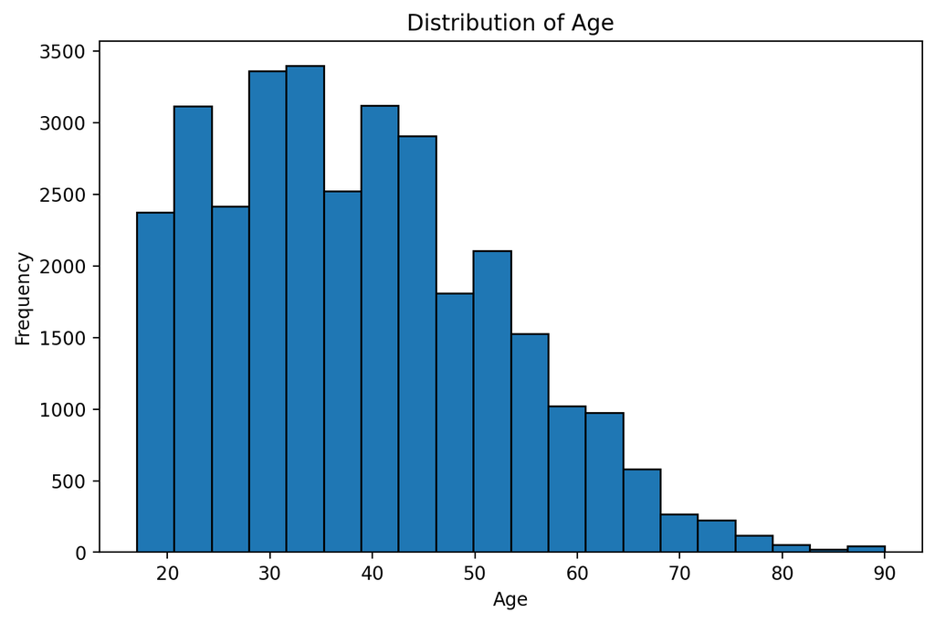

```python
#histogram for age
plt.figure(figsize=(8,5))
plt.hist(df["age"], bins=20, edgecolor="black")
plt.title("Distribution of Age")
plt.xlabel("Age")
plt.ylabel("Frequency")
plt.show()
```

The histogram shows how age is distributed in the dataset. Most individuals are concentrated in the adult working-age range, while fewer observations appear at very low or very high ages. This suggests the dataset is centered around middle-aged adults rather than being evenly spread across all ages.

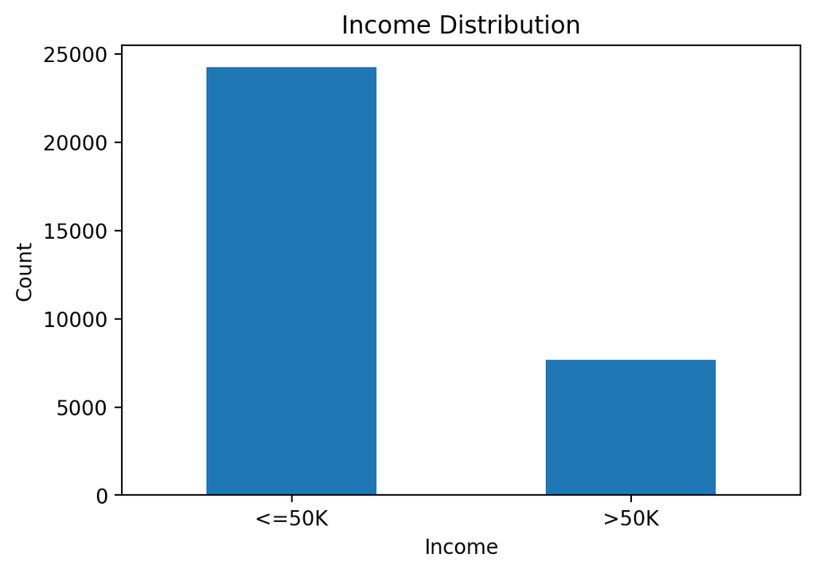

```python
#bar chart for income
income_counts = df["income"].value_counts()

plt.figure(figsize=(6,4))
income_counts.plot(kind="bar")
plt.title("Income Distribution")
plt.xlabel("Income")
plt.ylabel("Count")
plt.xticks(rotation=0)
plt.show()
```

The bar chart shows that there are more people in the lower income category than in the higher income category. This means the dataset is imbalanced, with most observations belonging to the group earning $50K or less.

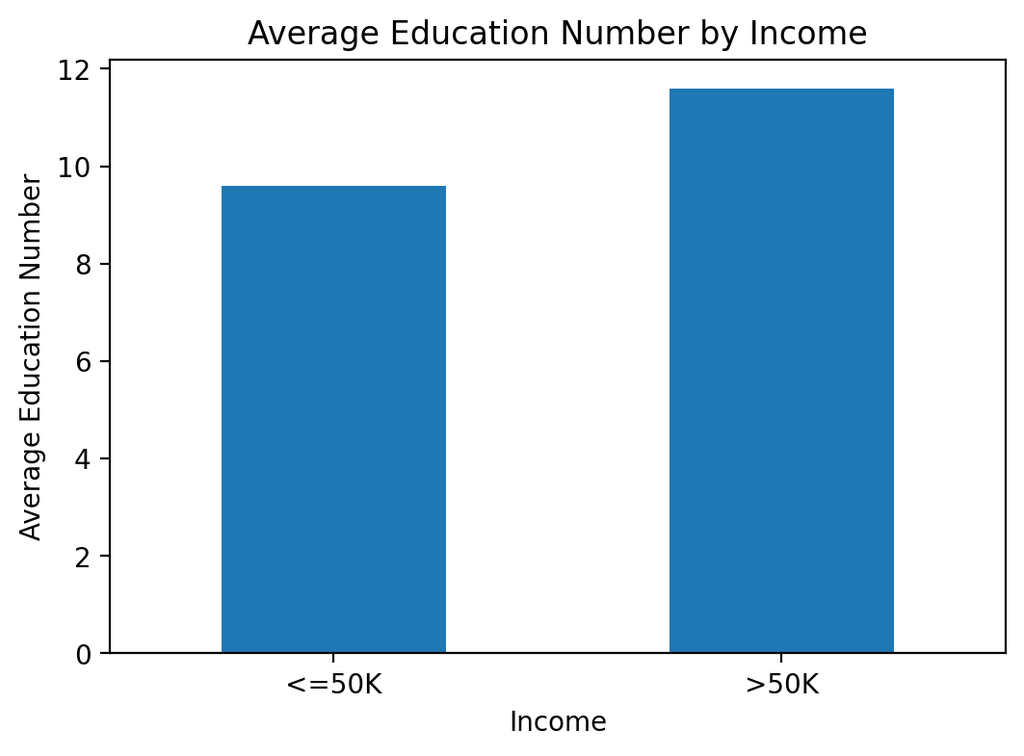

```python
grouped = df.groupby("income")["education.num"].mean()

plt.figure(figsize=(6,4))
grouped.plot(kind="bar")
plt.title("Average Education Number by Income")
plt.xlabel("Income")
plt.ylabel("Average Education Number")
plt.xticks(rotation=0)
plt.show()
```

This bar plot compares the average education number for each income group. The group earning above $50K has a higher average education number than the group earning $50K or less. This suggests that higher levels of education are associated with higher income in this dataset.

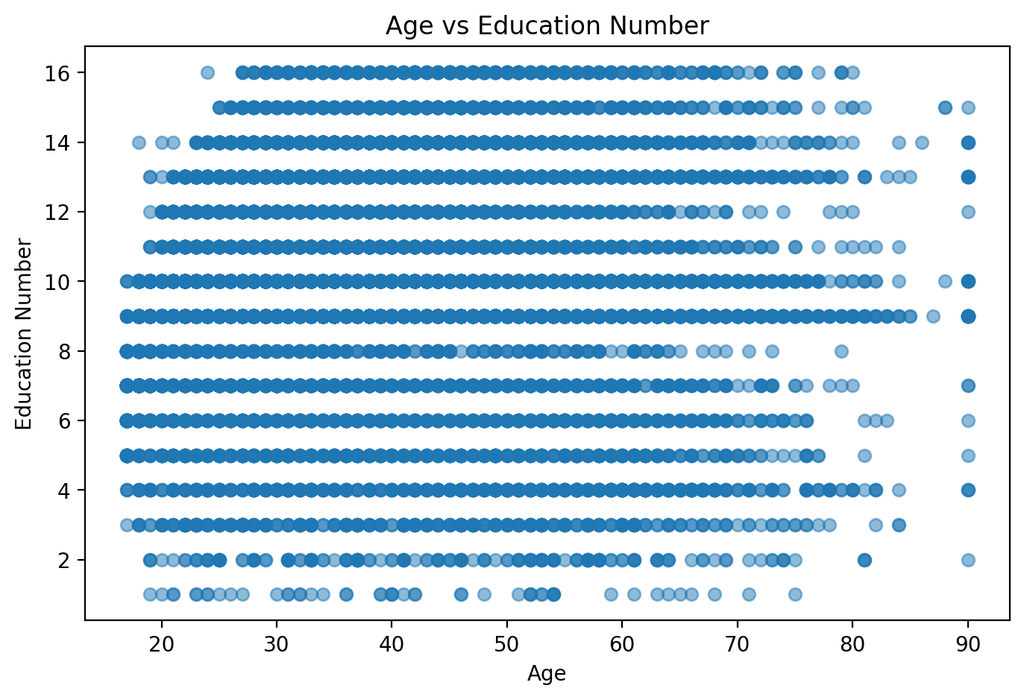

```python
#scatter plot: age vs education.num
plt.figure(figsize=(8,5))
plt.scatter(df["age"], df["education.num"], alpha=0.5)
plt.title("Age vs Education Number")
plt.xlabel("Age")
plt.ylabel("Education Number")
plt.show()
```

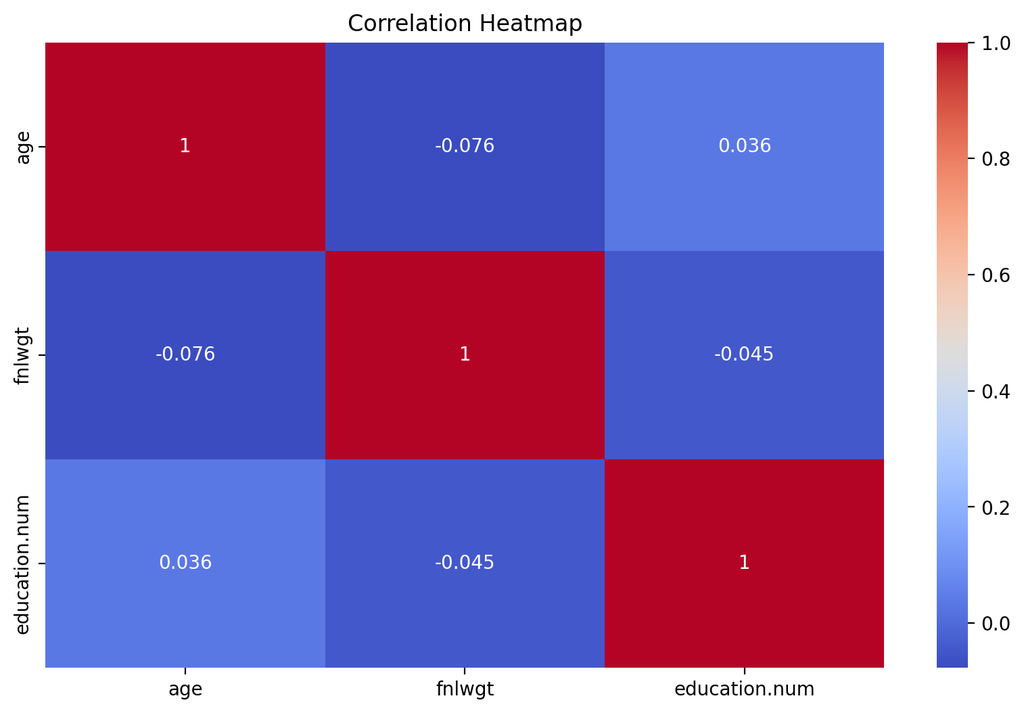

```python
#heatmap of correlations
import seaborn as sns

plt.figure(figsize=(10,6))
sns.heatmap(df.corr(numeric_only=True), annot=True, cmap="coolwarm")
plt.title("Correlation Heatmap")
plt.show()
```

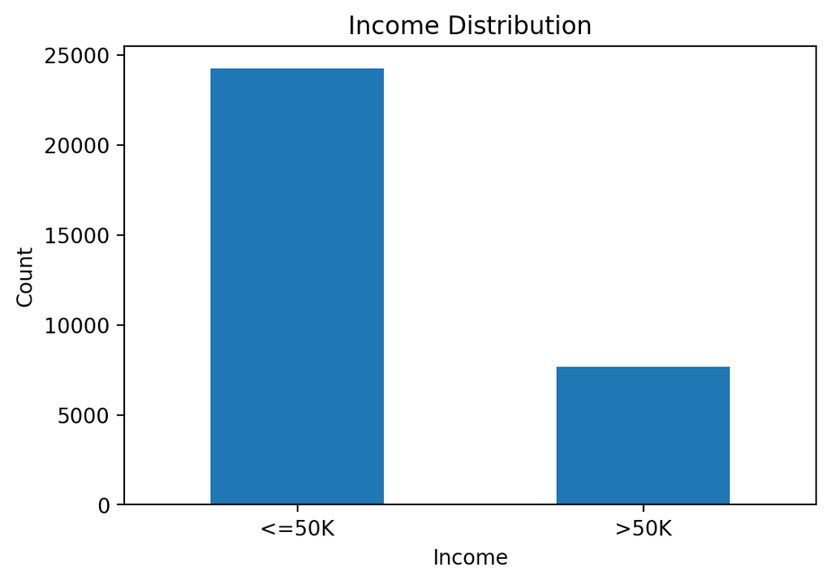

```python
#bar chart for income
income_counts = df["income"].value_counts()

plt.figure(figsize=(6,4))
income_counts.plot(kind="bar")
plt.title("Income Distribution")
plt.xlabel("Income")
plt.ylabel("Count")
plt.xticks(rotation=0)
plt.show()
```